# Classifying the Health of New York City Street Trees

STAT5003 Data Investigation Project · W12G04

Ziyan Chen

Chandrahaas Vellanki

Harshita Singh

Uma Sree Asritha Adari

Anas Howera

## Motivation : why investigate street-tree health?

## Street trees are valuable—but inspection capacity is limited

🌳

Hundreds of thousands of trees line NYC streets

🔎

Some require inspection or maintenance

⏱

Professional inspection of every tree takes time

Can routinely collected data help identify trees needing attention?

## Can observable characteristics classify perceived tree health?

Can tree characteristics, site conditions and geographic information classify living street trees as **Good**, **Fair**, or **Poor** health?

Good Fair Poor

**Goal:** a screening tool to support prioritisation—not replace professional inspection.

## The census provides scale and varied predictive signals

683,788

original records

652,172

living trees modelled

18

main predictors

🌿 **Tree**  
species, diameter 🏙 **Site**  
sidewalk, guards, stewardship 🩺 **Condition**  
root, trunk, branch problems 📍 **Location**  
borough, coordinates

Source: NYC Parks 2015 Street Tree Census. Health is available for living trees.

## Univariate analysis : which variables distinguish tree health?

## More recorded problems coincide with poorer health

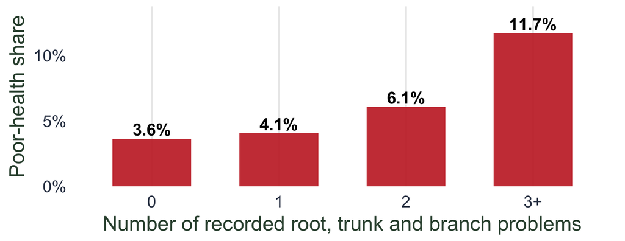

Poor health rises from **3.6%** with no recorded problem to **11.7%** with 3+ problems.

## Health patterns also differ substantially by species

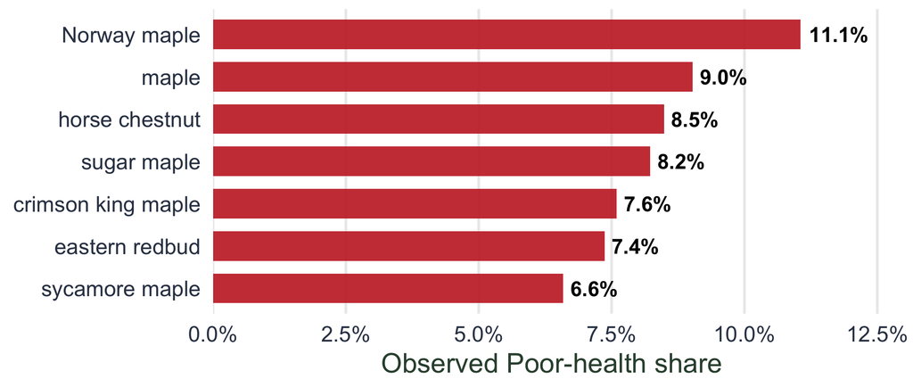

Multiple interacting characteristics—not one variable alone—appear relevant.

## Machine learning : sample splits and model construction

## Nearby trees were kept together—and the test set stayed untouched

**652,172**  
eligible trees

**521,746**  
80% development

**130,426**  
20% final test

**1. Keep nearby trees together**

Same street block stays in one partition

**2. Handle categories consistently**

Rare and unseen levels remain valid

**3. Reduce diameter skew**

Apply the transformation inside training

## We compared simple-to-flexible models on the same evidence

Logistic  
linear benchmark Naive Bayes  
probabilistic benchmark Decision Tree  
interpretable rules Random Forest  
many trees XGBoost  
sequential trees

Prepare features**→**Compare natural vs rebalanced training**→**Refine settings with grouped CV

## Better optimization : rebalancing the training procedure

## Accuracy alone was not enough

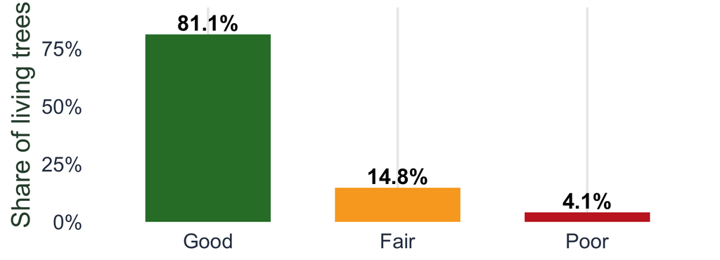

An always-**Good** prediction is 81.1% accurate—so accuracy alone is misleading.

We therefore selected models with **Macro-F1**, giving Good, Fair and Poor equal importance.

## Rebalancing made Poor-tree screening far more sensitive

Poor recall 5.2% → 52.9% +47.7 percentage points

Macro-F1 0.370 → 0.378 improved across the three classes

Accuracy 81.3% → 55.1% expected trade-off for minority detection

**Grouped 5-fold CV selected:** 228 trees · depth 7 · minimum node size 15 · learning rate 0.316

Rebalancing—not accuracy maximisation—made the model useful as a screening tool.

## Evaluation : how does our model perform?

## XGBoost narrowly led the cross-validation comparison

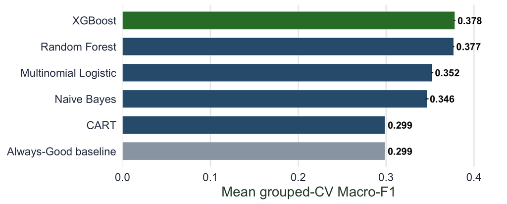

XGBoost (0.378) and Random Forest (0.377) were effectively very close.

## The selected model detected 55% of Poor trees in unseen blocks

0.380

Macro-F1

54.9%

Poor recall

0.623

Balanced accuracy

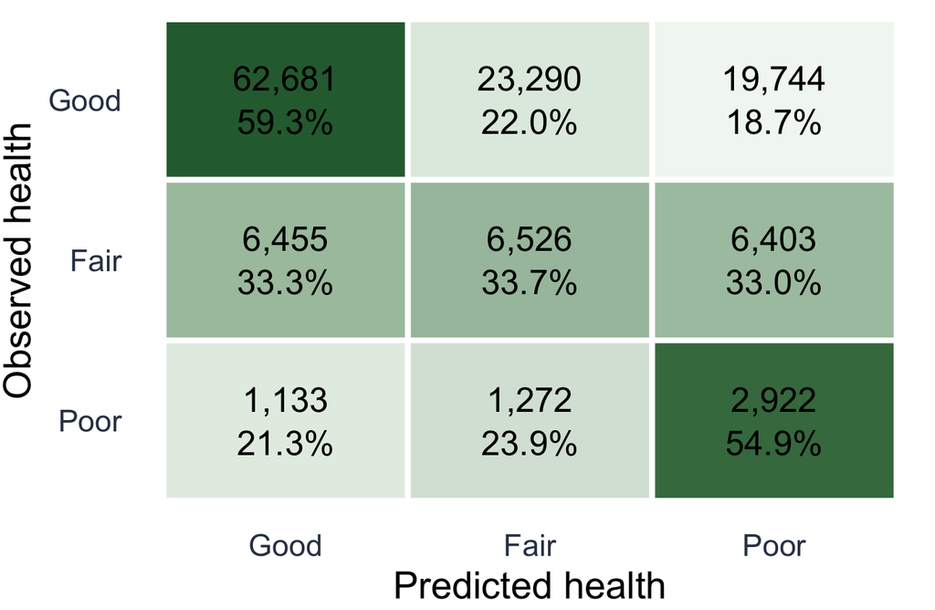

Screening sensitivity came with false alarms: Poor-class precision was 10.1%.

## Location and tree size carried most predictive signal

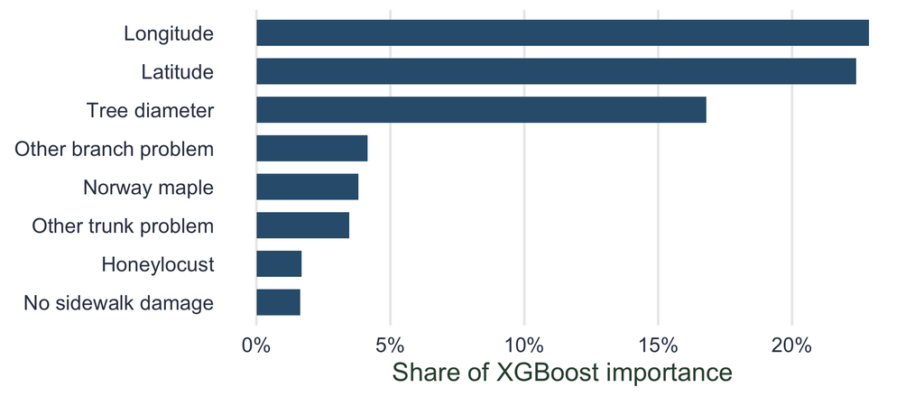

Location importance may limit transfer to another city or year.

Importance is predictive—not directional or causal.

## Thank you

Questions?

Observable characteristics help prioritise attention—but tree health still requires professional judgement.